# Rna-seq analysis. Homework

aslepchenkov

March 28, 2017

```r
library(DESeq2)
library(ggplot2)
library(clusterProfiler)
library(org.Hs.eg.db)
library(pheatmap)
library(plotly)
library(dplyr)
library(VennDiagram)
options(width = 120)
```

## Файлы с которыми будем работать сегодня

В ходе данной лекции нам понадобятся следующие файлы “GSE89225_illumina_counts.csv”, “conditions.csv”, “human_mart.txt”. Для начала убедимся в том, что мы можем эти файлы прочитать. И посмотрим, что в них находится.

```r
counts <- read.csv("GSE89225_Illumina_counts.csv", row.names=1)
conditions <- read.csv("conditions.csv", row.names=1)
mart <- read.table("human_mart.txt", sep="\t", header=1, check.names = F)

print(counts[1:6, 1:2])
```

```
##                 tconv_tumor_patient10 cd177negtreg_tumor_patient10
## ENSG00000000003                   510                          935
## ENSG00000000005                    25                            1
## ENSG00000000419                   613                          818
## ENSG00000000457                   269                          587
## ENSG00000000460                    55                          142
## ENSG00000000938                    36                           69
```

```r
dim(counts)
```

```
## [1] 63677    34
```

```r
head(conditions)
```

```
##                                            tissue                               cells
## tconv_tumor_patient10        tissue: breast tumor cell type: Conventional CD4 T cells
## cd177negtreg_tumor_patient10 tissue: breast tumor       cell type: Regulatory T cells
## cd177postreg_tumor_patient10 tissue: breast tumor       cell type: Regulatory T cells
## tconv_tumor_patient1         tissue: breast tumor cell type: Conventional CD4 T cells
## treg_tumor_patient1          tissue: breast tumor       cell type: Regulatory T cells
## tconv_NBP_patient2                    tissue: NBP cell type: Conventional CD4 T cells
```

```r
dim(conditions)
```

```
## [1] 34  2
```

```r
head(mart)
```

```
##           Gene ID Associated Gene Name Gene type EntrezGene ID
## 1 ENSG00000252303            RNU6-280P     snRNA            NA
## 2 ENSG00000281771                Y_RNA  misc_RNA            NA
## 3 ENSG00000281256         RP11-222G7.2   lincRNA            NA
## 4 ENSG00000283272      Clostridiales-1      sRNA            NA
## 5 ENSG00000280864        RP11-654C22.2   lincRNA            NA
## 6 ENSG00000280792        RP11-315F22.1   lincRNA            NA
```

```r
dim(mart)
```

```
## [1] 64101     4
```

Из-за большого отличия образца treg_NBP_patient3 от остальных, его было решено удалить

```r
counts$treg_NBP_patient3 <- NULL
conditions <- conditions[rownames(conditions) != "treg_NBP_patient3",]  # Just -"treg_NBP_patient3" doesn't work
```

# RNA-seq

Rna-seq steps:

- Изоляция РНК
- **Rna selection / depletion**
- **Фрагментация**
- Синтез кДНК
- Секвенирование

Rna selection / depletion:

- вся РНК
- тянем за поли(А)-хвосты (только мРНК)
- удаляем рибосомальную РНК (ribo-zero kit)
- таргетное секвенирование

Why Rna-seq?

- Не ограничены существующей сборкой и дизайном микрочипа
- Низкий фоновый сигнал
- Точность позволяет смотреть экспрессию отдельных изоформ

# Sanity checks

Нужно всегда проверять длины библиотек и количество rRNA reads, которые оказались в библиотеке. Количество ридов можно проверять после выравнивания или после квантификации.

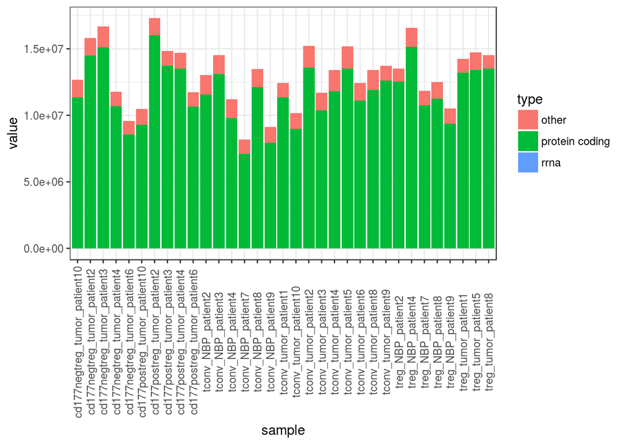

```r
proteinCoding <- mart[mart[, 3] == "protein_coding", ]
rRNA <- mart[mart[, 3] == "rRNA", ]
pcCounts <- counts[rownames(counts) %in% as.character(proteinCoding[, 1]), ]
rrnaCounts <- counts[rownames(counts) %in% as.character(rRNA[, 1]), ]

sampleCount <- ncol(counts)
toPlot <- data.frame(
  sample=rep(colnames(counts), 3),
  value=c(colSums(counts) - colSums(pcCounts) - colSums(rrnaCounts),
          colSums(pcCounts),
          colSums(rrnaCounts)),
  type=c(rep("other", sampleCount),
         rep("protein coding", sampleCount),
         rep("rrna", sampleCount))
)

plot <- ggplot(data=toPlot, aes(x=sample, y=value, fill=type)) +
  geom_bar(stat="identity") + theme_bw() +
  theme(axis.text.x = element_text(angle=90, vjust=0.5))
plot
```

# DESeq2

DESeq2 – это царь-библиотека необходимая для работы с данными RNA-seq. Тут и дифференциальная экспрессия, и нормализации, и PCA-plots.

```r
ncol(counts)
```

```
## [1] 33
```

```r
nrow(conditions)
```

```
## [1] 33
```

```r
dds <- DESeqDataSetFromMatrix(countData = counts,
                              colData = conditions,
                              design = ~ tissue + cells)
dds <- dds[rowSums(counts(dds)) > 20, ]
dds <- DESeq(dds)
vst_dds <- vst(dds)
counts.norm <- assay(vst_dds)
```

```r
pca_data <- prcomp(t(counts.norm))
percents <- pca_data$sdev^2 / sum(pca_data$sdev^2)
to_plot <- t(counts.norm) %*% pca_data$rotation

gdata <- data.frame(
  x=to_plot[, 1],
  y=to_plot[, 2],
  tissue=conditions[, 1],
  cells=conditions[, 2],
  name=rownames(conditions)
)

ggplotly(ggplot(data=gdata, aes(x=x, y=y, color=cells, shape=tissue, text=name)) +
  geom_point(size=3) + theme_bw()  +
  xlab(paste0("PC", 1, ": ", formatC(100 * percents[1], digits=4), "%")) +
  ylab(paste0("PC", 2, ": ", formatC(100 * percents[2], digits=4), "%")))
```

[interactive chart not shown]

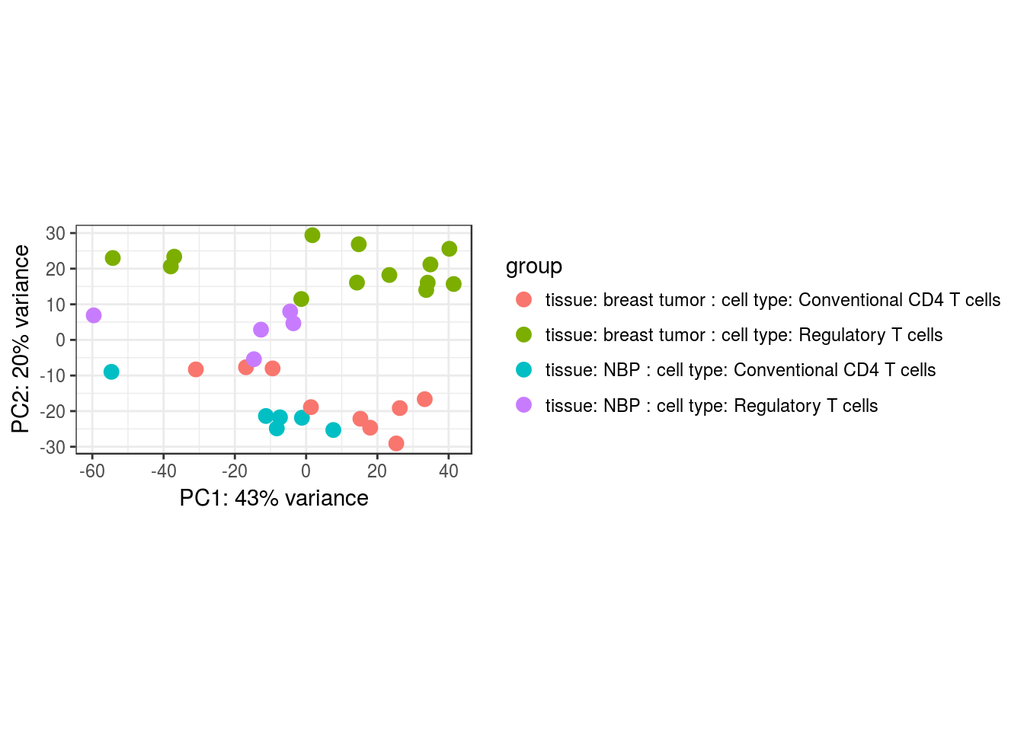

```r
plotPCA(vst_dds, intgroup=c("tissue", "cells")) + theme_bw()
```

# Differential expression

Давайте посмотрим, как выглядят результаты дифференциальной экспрессии и отсортируем их по статистике.

```r
cell_res <- results(dds)
mcols(cell_res)$description
```

```
## [1] "mean of normalized counts for all samples"
## [2] "log2 fold change (MAP): cells cell type: Regulatory T cells vs cell type: Conventional CD4 T cells"
## [3] "standard error: cells cell type: Regulatory T cells vs cell type: Conventional CD4 T cells"
## [4] "Wald statistic: cells cell type: Regulatory T cells vs cell type: Conventional CD4 T cells"
## [5] "Wald test p-value: cells cell type: Regulatory T cells vs cell type: Conventional CD4 T cells"
## [6] "BH adjusted p-values"
```

```r
cell_res <- cell_res[order(cell_res[, 4]), ]  # order by stat

tissue_res <- results(dds, contrast = list("tissuetissue..NBP", "tissuetissue..breast.tumor"))
mcols(tissue_res)$description
```

```
## [1] "mean of normalized counts for all samples"
## [2] "log2 fold change (MAP): tissuetissue..NBP vs tissuetissue..breast.tumor"
## [3] "standard error: tissuetissue..NBP vs tissuetissue..breast.tumor"
## [4] "Wald statistic: tissuetissue..NBP vs tissuetissue..breast.tumor"
## [5] "Wald test p-value: tissuetissue..NBP vs tissuetissue..breast.tumor"
## [6] "BH adjusted p-values"
```

```r
tissue_res <- tissue_res[order(tissue_res[, 4]), ]  # order by stat
```

Самый обычный способ визуализировать данные дифф.экспрессии – это volcano plot. По оси x мы будем откладывать log fold change, а по y - adjusted p value.

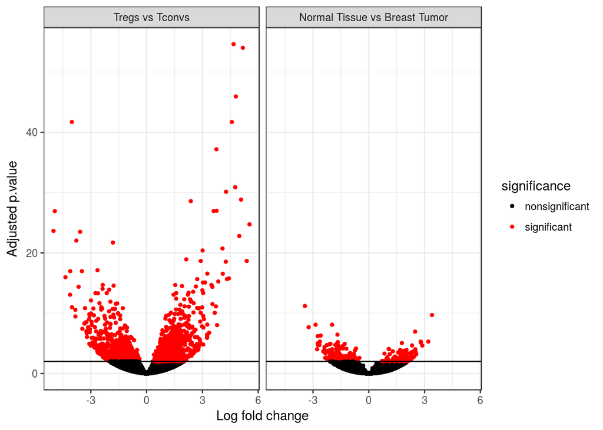

```r
cell_types_data <- data.frame(
  x = cell_res$log2FoldChange,
  y = -log10(cell_res$padj),
  significance = ifelse(cell_res$padj < 0.01, "significant", "nonsignificant"),
  comparison_type = "Tregs vs Tconvs"
)


tissue_types_data <- data.frame(
  x = tissue_res$log2FoldChange,
  y = -log10(tissue_res$padj),
  significance = ifelse(tissue_res$padj < 0.01, "significant", "nonsignificant"),
  comparison_type = "Normal Tissue vs Breast Tumor"
)

merged <- rbind(cell_types_data, tissue_types_data)

ggplot(data=merged, aes(x=x, y=y, colour = significance)) +
  geom_point(size=1) + theme_bw()  +
  xlab("Log fold change") +
  ylab("Adjusted p.value") +
  scale_color_manual(values = c( "nonsignificant" = "black", "significant" = "red"), limits = c("nonsignificant", "significant")) +
  geom_hline(aes(yintercept = -log10(0.01))) +
  facet_grid(. ~ comparison_type)
```

Также мы можем построить тепловую карту отсортировав гены по статистике

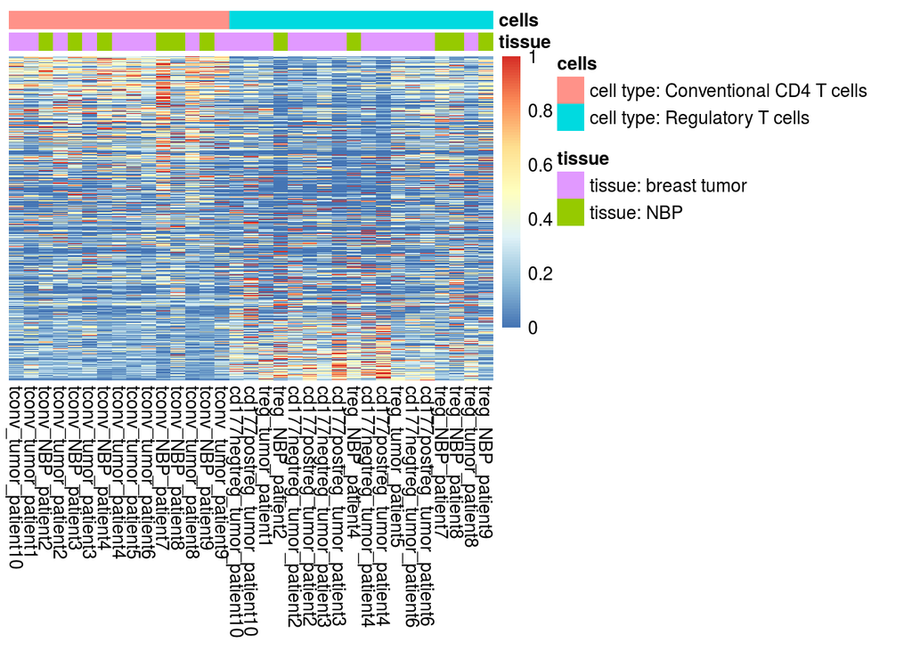

```r
counts.norm <- counts(dds, normalized=TRUE)
# png("heatmap_large.png", width=6, height=20, units="in", res=300)

to_visualise <- counts.norm[rownames(cell_res), order(conditions[, 2])]
to_visualise <- t(apply(to_visualise, 1, function(r) {
  (r - min(r)) / (max(r) - min(r))
}))

pheatmap(to_visualise,
         show_rownames = F, cluster_rows = F,
         cluster_cols=F,
         annotation_col = conditions)
```

```r
# dev.off()
```

```r
kkeys <- keys(org.Hs.eg.db, keytype = "ENSEMBL")
goAnno <- AnnotationDbi::select(org.Hs.eg.db, keys = kkeys,
                                keytype = "ENSEMBL", columns = c("GOALL", "ONTOLOGYALL", "SYMBOL"))
goAnno <- tbl_df(goAnno)
goAnno <- filter(goAnno, GOALL == "GO:0007159")

genesToVisualise <- goAnno$ENSEMBL
```

А теперь отобразим на хитмапе только гены из метаболического пути GO:0007159

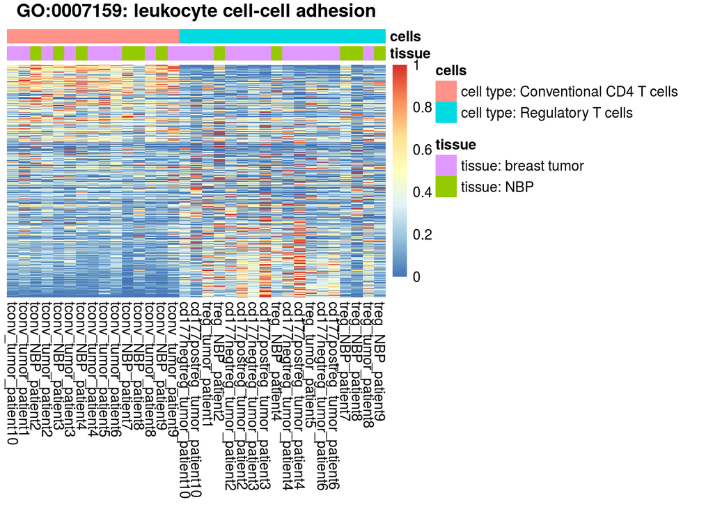

```r
# cell_res is already ordered by stat
to_visualise_pathway <- counts.norm[rownames(cell_res), order(conditions[, 2])]
to_visualise_pathway <- to_visualise_pathway[rownames(to_visualise_pathway) %in% genesToVisualise,]

to_visualise_pathway <- t(apply(to_visualise_pathway, 1, function(r) {
  (r - min(r)) / (max(r) - min(r))
}))

pheatmap(to_visualise_pathway,
         show_rownames = F, cluster_rows = F,
         cluster_cols=F,
         annotation_col = conditions,
         main = "GO:0007159: leukocyte cell-cell adhesion")
```

# clusterProfiler

Библиотека содержит в себе большое количество утилит для аннотации наборов генов.

```r
genes <- bitr(rownames(cell_res),
              fromType = "ENSEMBL",
              toType = c("ENTREZID", "SYMBOL"),
              OrgDb = org.Hs.eg.db)
head(genes)
```

```
##            ENSEMBL ENTREZID SYMBOL
## 2  ENSG00000113088     3003   GZMK
## 4  ENSG00000026751    57823 SLAMF7
## 6  ENSG00000133302    84250   SLF1
## 7  ENSG00000164398    23305  ACSL6
## 8  ENSG00000145649     3001   GZMA
## 10 ENSG00000100450     2999   GZMH
```

```r
genes <- genes[!duplicated(genes[, 1]), ]
rownames(genes) <- genes[, 1]
cell_res$ENSEMBL <- rownames(cell_res)

merged <- merge(as.data.frame(cell_res), genes)
head(merged)
```

```
##           ENSEMBL   baseMean log2FoldChange     lfcSE       stat       pvalue         padj ENTREZID   SYMBOL
## 1 ENSG00000000003 423.163296     0.63538202 0.4920649  1.2912564 1.966148e-01 4.115223e-01     7105   TSPAN6
## 2 ENSG00000000005   8.893115    -0.14072871 0.5653427 -0.2489264 8.034177e-01 9.019086e-01    64102     TNMD
## 3 ENSG00000000419 848.545987     0.19179247 0.1553810  1.2343366 2.170775e-01 4.367093e-01     8813     DPM1
## 4 ENSG00000000457 418.002766    -0.20724425 0.2863086 -0.7238491 4.691584e-01 6.782815e-01    57147    SCYL3
## 5 ENSG00000000460 255.889945     1.03038790 0.2109222  4.8851554 1.033473e-06 5.029308e-05    55732 C1orf112
## 6 ENSG00000000938  31.380430     0.05804885 0.5780237  0.1004264 9.200058e-01 9.640626e-01     2268      FGR
```

Давайте что-нибудь узнаем о дифф.экспрессированных генах!

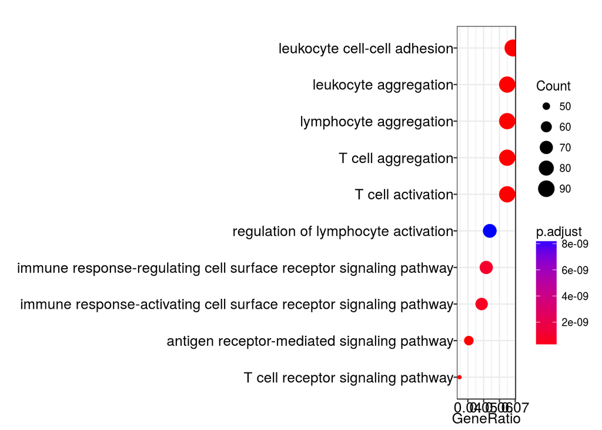

```r
diffExpGenes <- merged[which(merged$padj < 0.01), 8]
universe <- as.character(merged[, 8])

ego <- enrichGO(gene          = diffExpGenes,
                universe      = universe,
                OrgDb         = org.Hs.eg.db,
                ont           = "BP",
                pAdjustMethod = "BH",
                pvalueCutoff  = 0.01,
                qvalueCutoff  = 0.05,
        readable      = TRUE)
# head(ego)
dotplot(ego)
```

Построим диаграммы вена чтобы оценить оценить, есть ли у сравнений Tumor tissue vs normal tissue и Treg vs Tconv общие дифференциально экспрессированные гены.

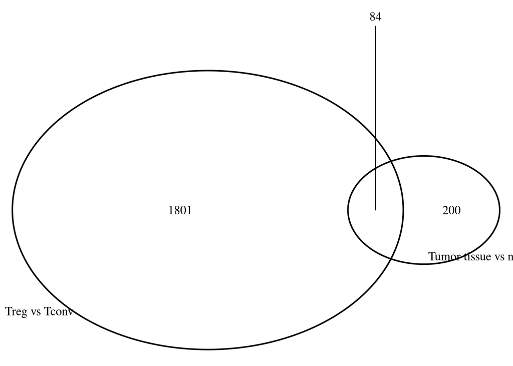

```
## (polygon[GRID.polygon.356], polygon[GRID.polygon.357], polygon[GRID.polygon.358], polygon[GRID.polygon.359], text[GRID.text.360], text[GRID.text.361], text[GRID.text.362], lines[GRID.lines.363], text[GRID.text.364], text[GRID.text.365])
```

```r
cell_res = na.omit(cell_res)  # remove all entries without padj and other columns
cell_res_significant = cell_res[cell_res$padj < 0.01, ]
tissue_res = na.omit(tissue_res)
tissue_res_significant = tissue_res[tissue_res$padj < 0.01, ]

tissue_genes <-  rownames(tissue_res_significant)
cell_genes <- rownames(cell_res_significant)
common_genes <- intersect(tissue_genes, cell_genes)

draw.pairwise.venn(length(tissue_genes), length(cell_genes), length(common_genes),
                   category = c("Tumor tissue vs normal tissue", "Treg vs Tconv"))
```